# Mercado de Trabalho Portuário

Agosto de 2024

Autor

Observatório Portuário

# 1 Dinâmica do Mercado de Trabalho Portuário no Brasil

O número de admitidos no mês foi de 2448, enquanto o de desligados foi de 1730, o que resultou em um saldo (diferença entre admitidos e desligados ) de 718 postos de trabalho no setor portuário no país.

Ao considerar as regiões do país, observa-se que o desempenho no Sudeste foi de 473 vínculos de saldo, resultado de 1303 admitidos e 830 desligados. No Nordeste, o saldo total foi de 95 vínculos, com 244 admitidos e 149 desligados.

Na região Norte, o saldo foi de 66 vínculos, com 511 admitidos e 445 desligados. Já na região Sul, o resultado foi de 60 vínculos, sendo 339 admitidos e 279 desligados. Por fim, a região Centro-Oeste apresentou um saldo de 24 vínculos, com 51 admitidos e 27 desligados.

Ao considerar o Gráfico 1, verifica-se as respectivas movimentações de admitidos e desligados por região.

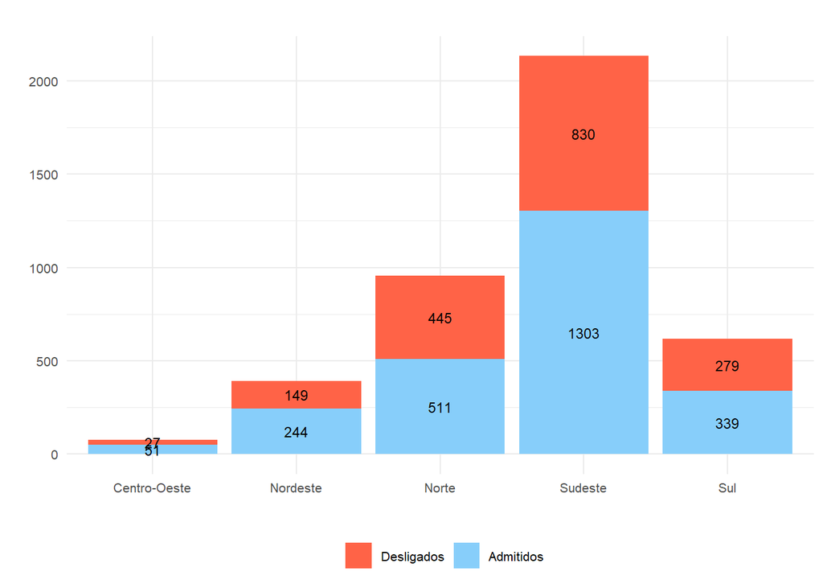

Gráfico 1: Movimentação de vínculos por região

Ao analisar o desempenho por unidade da federação, o Gráfico 2 mostra o desempenho de cada estado no mês.

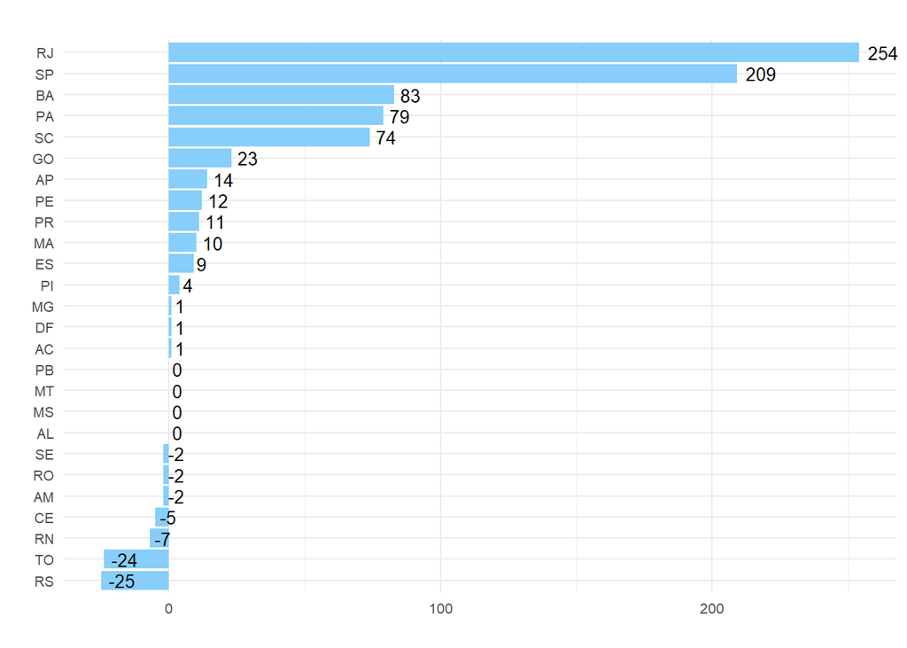

Gráfico 2: Saldo por estado

Os gráficos acima apresentam a distribuição de movimentações de vínculos em diferentes unidades federativas e em suas respectivas regiões. A análise permite identificar variações na quantidade de movimentações, evidenciando tanto aumentos quanto reduções em cada estado e região. Esse panorama facilita a compreensão do desempenho regional no mês.

O Gráfico 3, por sua vez, apresenta a distribuição da mediana salarial mensal para admitidos e desligados nas diferentes regiões do Brasil. Os boxplots permitem visualizar a variação dos salários dentro de cada grupo, destacando a mediana, os quartis e os possíveis valores atípicos. Essa análise comparativa entre admitidos e desligados em cada região oferece uma perspectiva das diferenças salariais, ajudando a identificar tendências regionais.

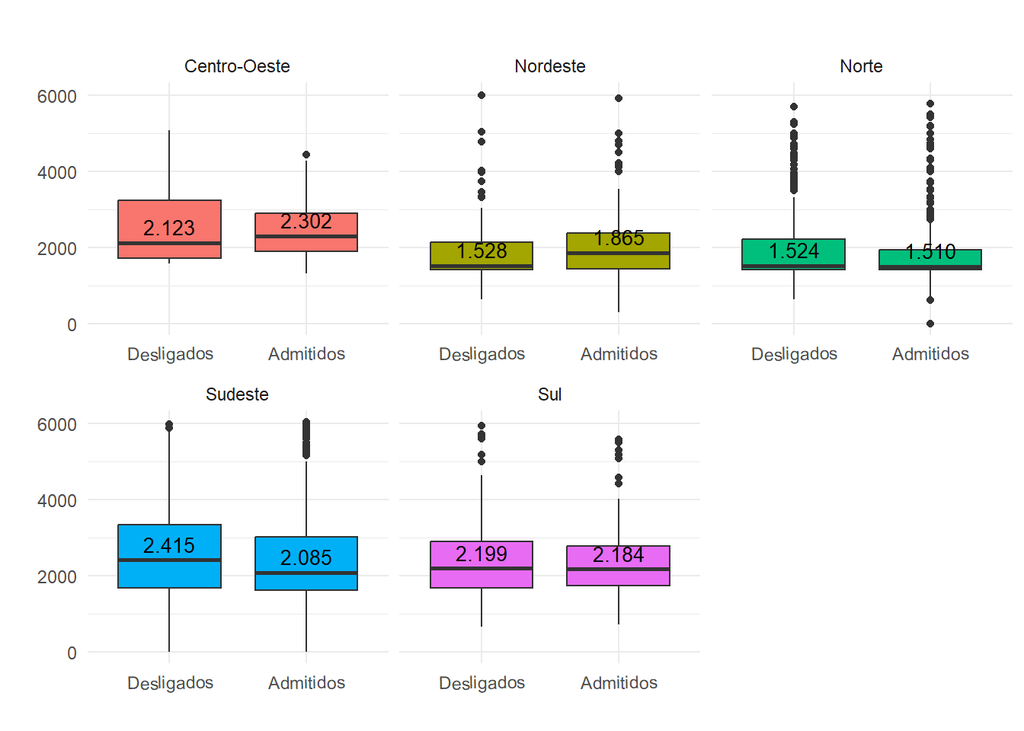

Gráfico 3: Mediana salarial mensal por região (R$)

O Gráfico 4 apresenta a distribuição de admissões e desligamentos no mercado de trabalho pelo recorte de sexo. As barras empilhadas indicam o número total de movimentações, permitindo uma comparação visual entre os grupos de homens e mulheres. Essa visualização facilita a análise das dinâmicas de contratação e desligamento, possibilitando a identificação de tendências de inclusão ou exclusão no mercado de trabalho de acordo com o sexo de cada trabalhador.

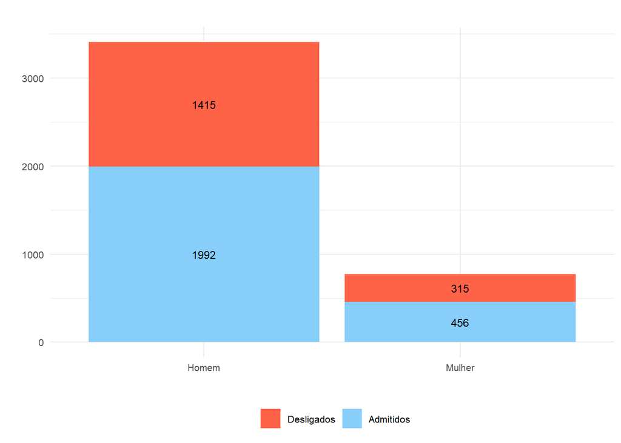

Gráfico 4: Saldo de movimentações por sexo

O Gráfico 5, por sua vez, mostra a distribuição de admissões e desligamentos no mercado de trabalho, segmentada por diferentes níveis de escolaridade, no Brasil. As barras empilhadas mostram o total de movimentações para cada nível educacional, permitindo uma análise comparativa sobre como o grau de instrução influencia a dinâmica de contratação e desligamento, o que pode indicar padrões de empregabilidade na força de trabalho.

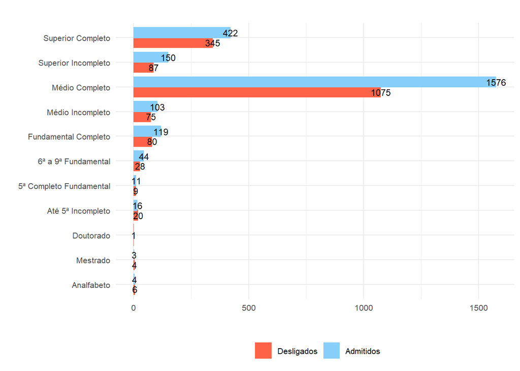

Gráfico 5: Movimentações por grau de escolaridade no país

O Gráfico 6 apresenta as 10 ocupações que registraram o maior saldo positivo de movimentações no mês no país, indicando um maior número de admissões em relação aos desligamentos. Cada barra representa uma ocupação e está segmentada em admissões e desligamentos, permitindo uma análise clara das profissões com maior demanda. Isso auxilia na identificação de tendências de crescimento e setores com maior contratação.

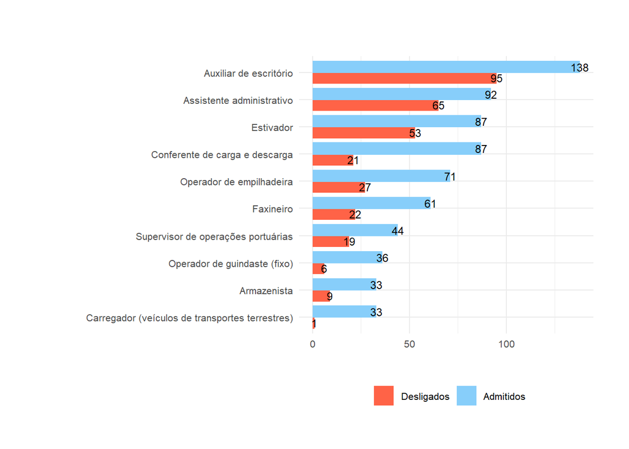

Gráfico 6: 10 ocupações com saldo positivo no mês

O Gráfico 7, por sua vez, mostra as 10 (dez) ocupações com o maior saldo negativo de movimentações no mês, mostrando profissões onde os desligamentos superaram as admissões. Essa informação é útil para identificar áreas de instabilidade e potencial necessidade de intervenções ou requalificação ou eventuais crises conjunturais.

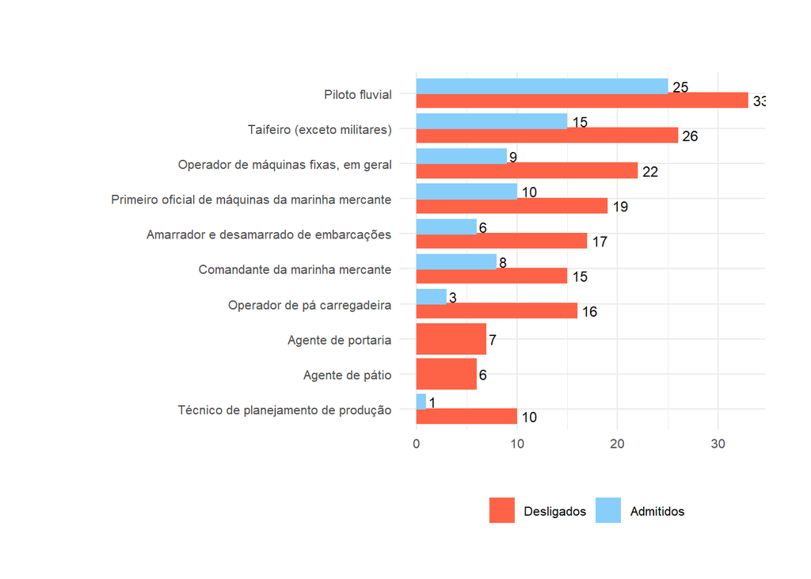

Gráfico 7: 10 ocupações com saldo negativo no mês

# 2 Mercado de Trabalho Portuário no Maranhão

O Gráfico 8 mostra a evolução da movimentação e o respectivo saldo de vínculos no estado, mostrando a tendência geral dos processos de admissão e demissão.

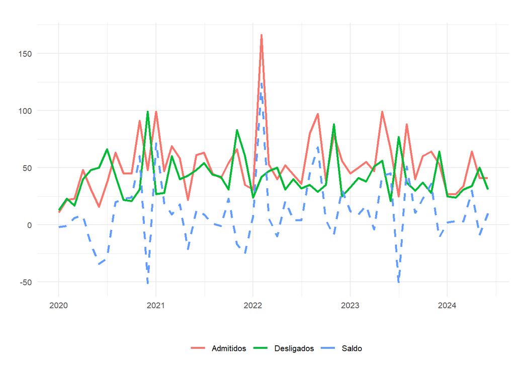

Gráfico 8: Evolução dos vínculos no Maranhão

| Mês | Desligados | Admitidos | Saldo |
| --- | --- | --- | --- |
| jun 2024 | 31 | 41 | 10 |
| mai 2024 | 50 | 41 | -9 |
| abr 2024 | 34 | 64 | 30 |
| mar 2024 | 31 | 34 | 3 |
| fev 2024 | 24 | 27 | 3 |
| jan 2024 | 25 | 27 | 2 |
| dez 2023 | 64 | 53 | -11 |
| nov 2023 | 28 | 64 | 36 |
| out 2023 | 37 | 60 | 23 |
| set 2023 | 30 | 40 | 10 |
| ago 2023 | 37 | 88 | 51 |

Por sua vez, observa-se no Gráfico 9 o desempenho do estado do Maranhão no quesito salarial.

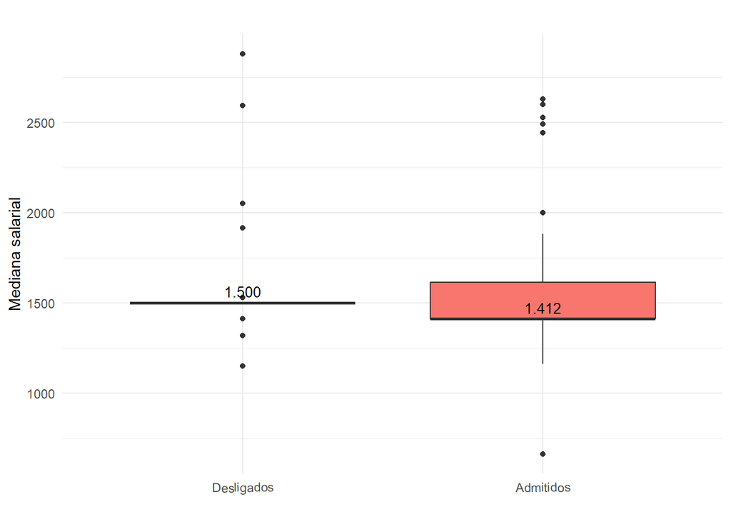

Gráfico 9: Mediana do salário mensal no Maranhão (R$)

No Gráfico 10 estão os dados das movimentações por sexo para o mês vigente no Maranhão.

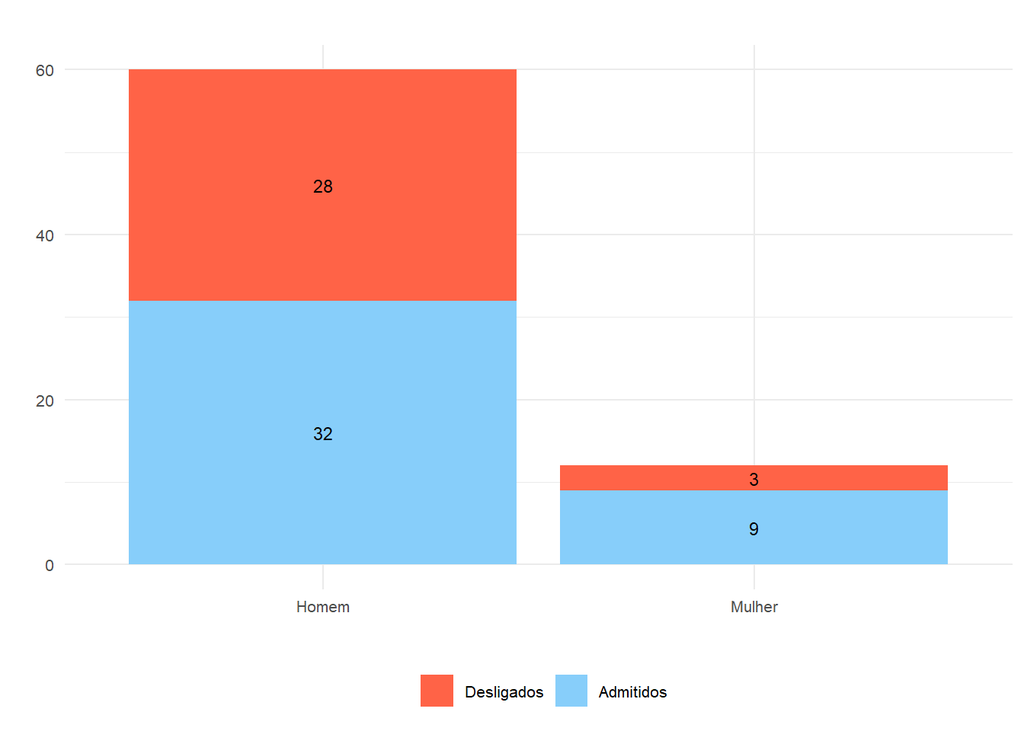

Gráfico 10: Saldo de movimentações por sexo no Maranhão

Ao observar as movimentações por grau de escolaridade, tem-se os valores conforme se observa no Gráfico 11.

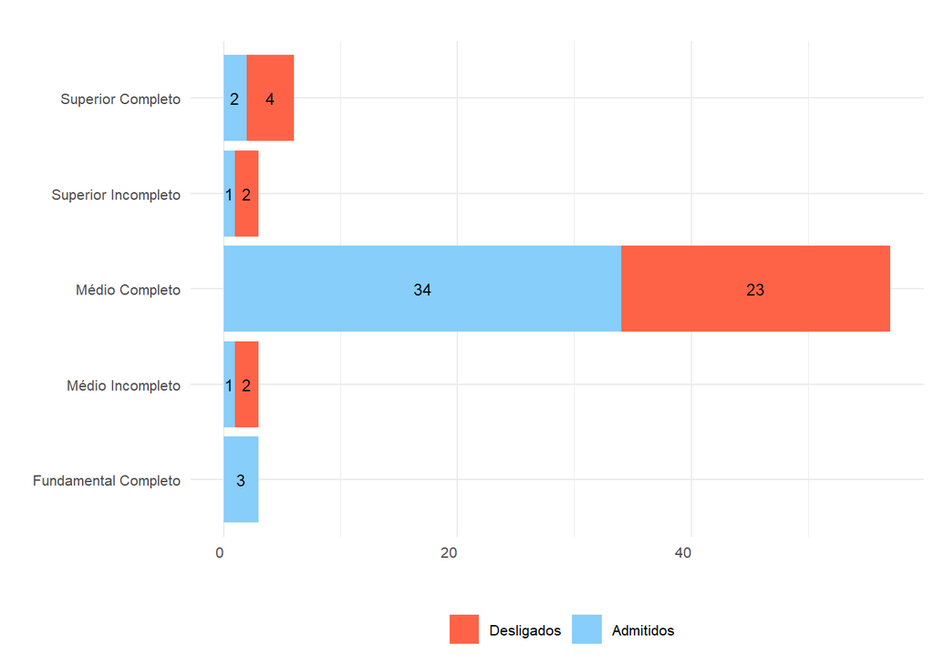

Gráfico 11: Movimentações por grau de escolaridade no Maranhão

[figure not shown]

[figure not shown]